# Changes in fish body sizes relate to temperature, but not all species shrink with warming

Asta Audzijonyte, Shane Richards, Julia Blanchard et al.

22 March 2018

This document is an electronic supplement to the NEE submission NATECOLEVOL-19108348-T. The document contains unpublished code and data. Please use it only for review purposes.

### Load datafiles

```
## [1] 335
```

### Extended Data Fig1: map data and sites

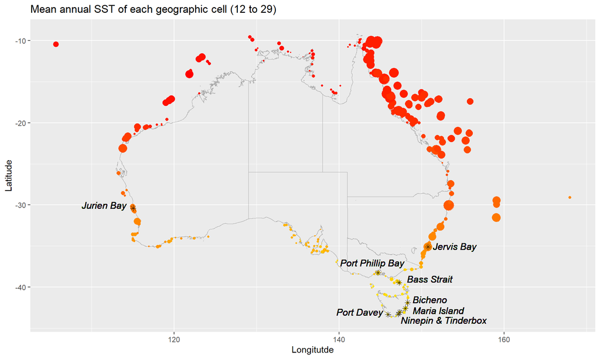

### Daily SST values to get temperature statistics

This chunk does not have to be run because the main datafile already has SST statistics associated with each geographic cell. However, it is included here in case someone wants to do different analyses or calcualte different temperature statistics. Thanks to Mike Sumner (Australian Antarctic Division) for help with the SST data!

### Extended Data Fig.2: are species distributed lognormally? Mostly

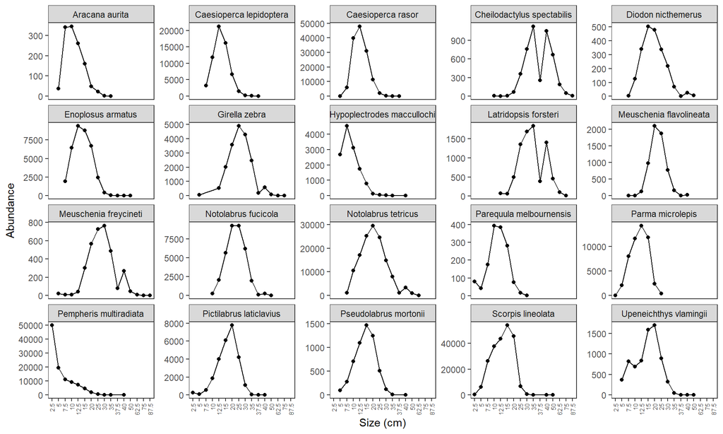

### Extended Data Fig.3: Plot size-temperature distributions in space

Two example plots are provided in the manuscript electronic supplement. Plots for all species are available on https://github.com/astaaudzi/RLSfishSize/tree/master/AllSizePlots

### First set of Bayesian analyses: split the data

Based on initial analyses, some species need higher or lower priors to ensure that their posteriors are within priors. This chunk does not need to be run now, because final estimates of slopes are provided

### First set of Bayesian analyses: main analysis code

The data files above were analysed on clusters and this is the code to be run for the main spatial analysis. Analyses don’t have to be run here because ouputs are saved and available. The main analysis is done using the spatial_main.stan code. For some species spatial analyses had to be repeated with updated priors (higher b0 or lower b0) and related .stan files are named accordingly

### STAN code for the spatial analyses

NOTE! This does not run in R, but has to be supplied as .stan file. All files are available in the stan_models subfolder

### Spatial postanalyses processing: traceplots

this code was used to assess convergence; individual species traceplots are not provided here, but can be reproduced using the chunks above and this code

### Extract posterior distribution quantiles from individual Bayesian analyses

this chunk does not need to be run because outputs are saved and provided separately

### Extended Data Table1: print spatial slopes

| species | MaxObservLength | preferred_temp | b1_p025 | b1_p10 | b1_p50 | b1_p90 | b1_p975 |
| --- | --- | --- | --- | --- | --- | --- | --- |
| Abudefduf bengalensis | 20.00 | 25.71525 | -0.0140009 | -0.0079656 | 0.0027078 | 0.0134342 | 0.0188546 |
| Abudefduf sexfasciatus | 20.00 | 24.70350 | -0.0042279 | 0.0044604 | 0.0197550 | 0.0348806 | 0.0437173 |
| Abudefduf vaigiensis | 20.00 | 25.15700 | -0.0253585 | -0.0179460 | -0.0025954 | 0.0131721 | 0.0211051 |
| Abudefduf whitleyi | 15.00 | 24.57750 | -0.0543103 | -0.0341465 | -0.0009060 | 0.0280308 | 0.0460165 |
| Acanthaluteres brownii | 35.00 | 18.86600 | -0.0241864 | -0.0078599 | 0.0213287 | 0.0506357 | 0.0669108 |
| Acanthaluteres spilomelanurus | 20.00 | 16.55550 | -0.0035090 | 0.0304609 | 0.1042290 | 0.1773272 | 0.2111006 |
| Acanthaluteres vittiger | 40.00 | 17.29350 | -0.0718424 | -0.0601480 | -0.0393869 | -0.0208875 | -0.0101956 |
| Acanthochromis polyacanthus | 15.00 | 27.21300 | -0.0363343 | -0.0199261 | 0.0109667 | 0.0432929 | 0.0620044 |
| Acanthopagrus australis | 40.00 | 20.53350 | -0.1013493 | -0.0842321 | -0.0545989 | -0.0235962 | -0.0099257 |
| Acanthurus albipectoralis | 35.00 | 23.81950 | 0.0877573 | 0.1075289 | 0.1440638 | 0.1814321 | 0.2022987 |
| Acanthurus blochii | 40.00 | 27.29140 | -0.0173767 | -0.0082547 | 0.0119258 | 0.0313648 | 0.0423972 |
| Acanthurus dussumieri | 50.00 | 24.65625 | 0.0676454 | 0.0844893 | 0.1116453 | 0.1383014 | 0.1527182 |
| Acanthurus grammoptilus | 40.00 | 27.09050 | -0.0183363 | -0.0098912 | 0.0047399 | 0.0191244 | 0.0271376 |
| Acanthurus lineatus | 40.00 | 27.68060 | -0.0584674 | -0.0412137 | -0.0074997 | 0.0251446 | 0.0450223 |
| Acanthurus nigricans | 30.00 | 27.44120 | -0.0586003 | -0.0429258 | -0.0195155 | 0.0038889 | 0.0159296 |
| Acanthurus nigricauda | 40.00 | 28.23000 | -0.1362186 | -0.1154674 | -0.0747026 | -0.0363455 | -0.0157511 |
| Acanthurus nigrofuscus | 30.00 | 25.90630 | 0.0119701 | 0.0192558 | 0.0329508 | 0.0470060 | 0.0547427 |
| Acanthurus nigroris | 15.00 | 26.84785 | -0.0939123 | -0.0720618 | -0.0318548 | 0.0034112 | 0.0261710 |
| Acanthurus olivaceus | 32.50 | 24.72600 | 0.0621231 | 0.0764720 | 0.1057844 | 0.1382902 | 0.1556052 |
| Acanthurus pyroferus | 25.00 | 27.82750 | -0.0295298 | -0.0138251 | 0.0175081 | 0.0516344 | 0.0696838 |
| Acanthurus triostegus | 25.00 | 26.84580 | -0.0296412 | -0.0167584 | 0.0044960 | 0.0259349 | 0.0376448 |
| Achoerodus gouldii | 125.00 | 18.18300 | 0.0372164 | 0.0520924 | 0.0817009 | 0.1089266 | 0.1236250 |
| Achoerodus viridis | 131.25 | 19.38900 | 0.0259859 | 0.0387531 | 0.0660374 | 0.0908561 | 0.1084652 |
| Amblyglyphidodon curacao | 12.50 | 27.70190 | -0.1393953 | -0.1217870 | -0.0910118 | -0.0610774 | -0.0433455 |
| Amblyglyphidodon leucogaster | 15.00 | 28.45800 | -0.1020503 | -0.0727380 | -0.0176661 | 0.0359437 | 0.0709658 |
| Amblygobius phalaena | 15.00 | 25.40800 | -0.0445211 | -0.0287275 | -0.0013412 | 0.0255371 | 0.0383443 |
| Amphiprion akindynos | 12.50 | 24.61550 | -0.0371403 | -0.0170046 | 0.0228064 | 0.0673616 | 0.0958235 |
| Anampses elegans | 25.00 | 21.54150 | -0.2454046 | -0.1940041 | -0.0919951 | 0.0223432 | 0.1036277 |
| Anampses geographicus | 30.00 | 23.55250 | -0.0351559 | -0.0279123 | -0.0135939 | 0.0013856 | 0.0094538 |
| Anampses neoguinaicus | 20.00 | 24.29100 | -0.0013342 | 0.0061987 | 0.0222680 | 0.0390460 | 0.0469935 |

[output cut: 305 more lines]

### Fig1A: second spatial Bayesian analysis, effects of temperature midpoint

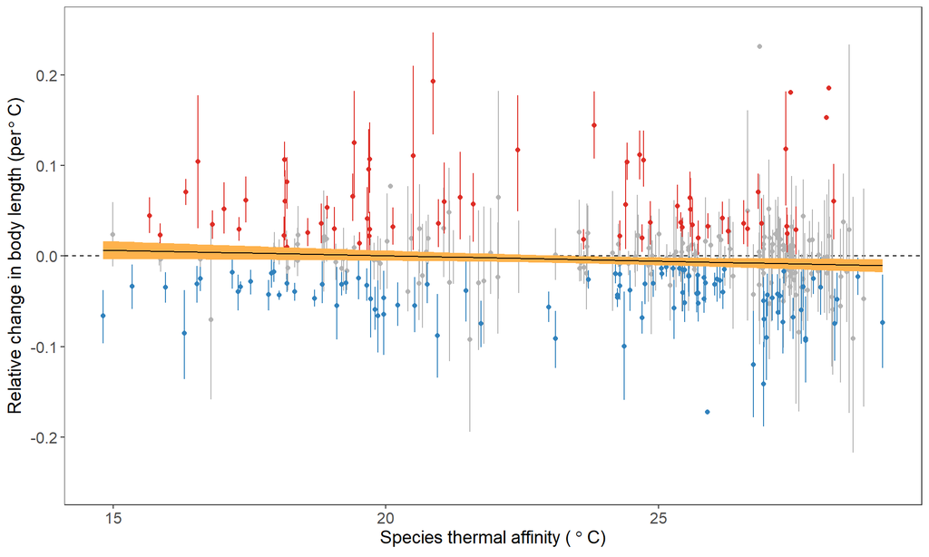

### Fig1B: second spatial Bayesian analysis, effects of maximum body size

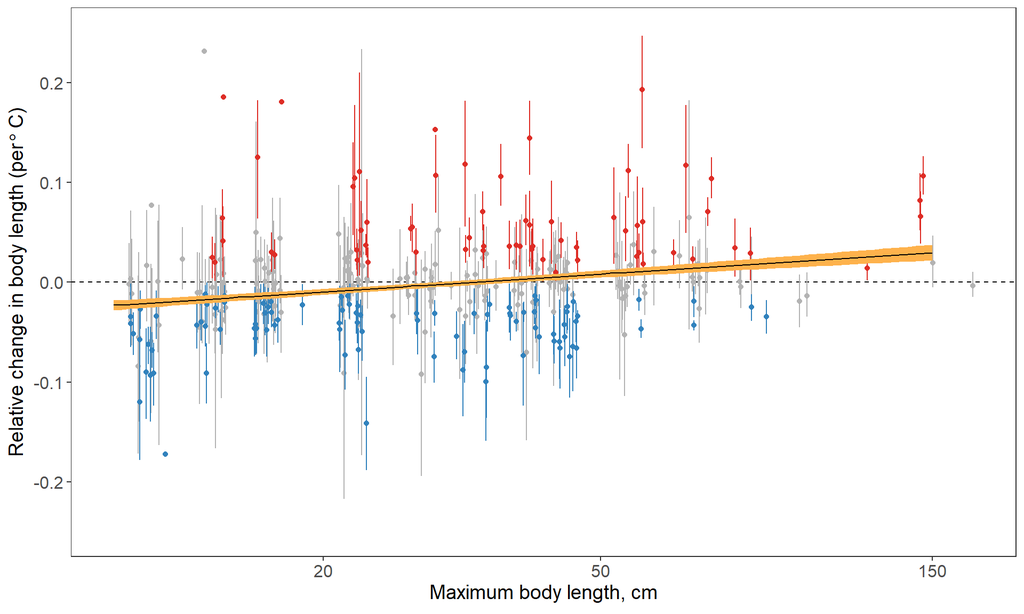

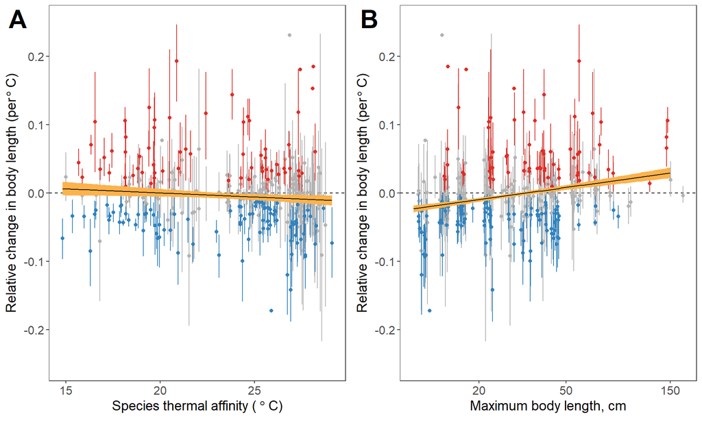

### Extended Data Fig 7: testing if exclusion of juveniles might affect Fi1B results

The full analysis is not given here, as it is a repeat of the analysis above for 20 species, but with all size data included. First get the data

And then plot

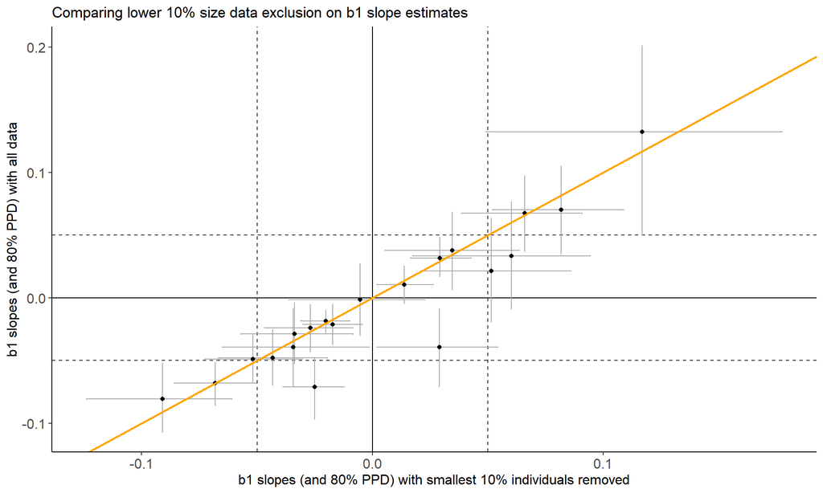

Also here are results of the second hierarchical Bayesian analsyes when the data for 20 species was replaced with new slope estimates

*Bayesian results with 20 values replaced without data exclusion* mean se_mean sd 2.5% 50% 97.5% n_eff Rhat beta0 -0.00496 0.00007 0.00198 -0.00877 -0.00501 -0.00101 768 0.99744 beta1 0.01828 0.00012 0.00342 0.01157 0.01828 0.02469 874 1.00176 sigma 0.02805 0.00006 0.00180 0.02449 0.02807 0.03150 971 0.99840

*Bayesian result of the original analysis* mean se_mean sd 2.5% 50% 97.5% n_eff Rhat beta0 -0.00484 0.00007 0.00197 -0.00868 -0.00479 -0.00117 826 1.00231 beta1 0.01948 0.00011 0.00334 0.01330 0.01937 0.02585 973 0.99698 sigma 0.02811 0.00007 0.00180 0.02477 0.02811 0.03161 757 1.00706

### Extended Data Fig. 4: correlation to abundance skew

```
##
##  Pearson's product-moment correlation
##
## data:  bet1ci$skew and bet1ci$p50
## t = 1.4922, df = 298, p-value = 0.1367
## alternative hypothesis: true correlation is not equal to 0
## 95 percent confidence interval:
##  -0.02738745  0.19743585
## sample estimates:
##        cor
## 0.08612048
```

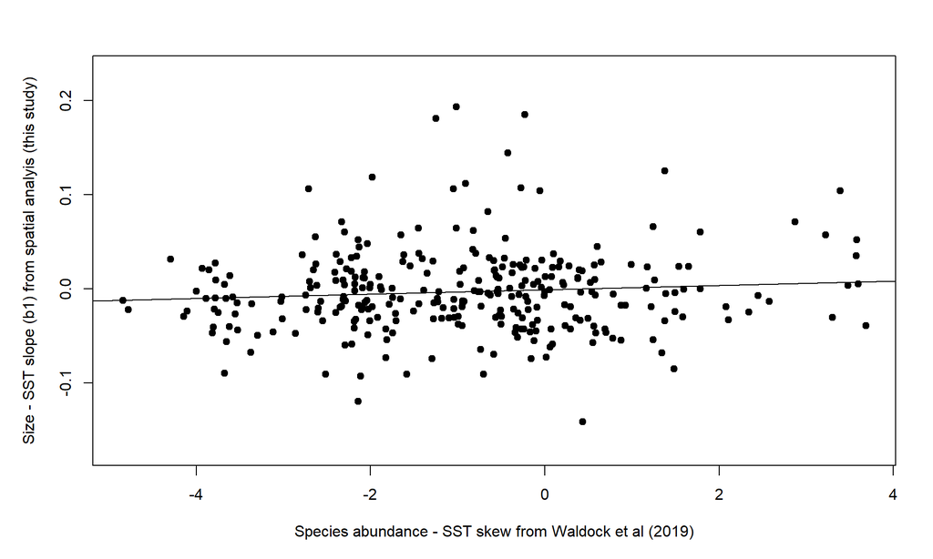

### Extended Data Table 2: long term SST trends

### Table of long-term SST trends

| Loc | Mean | q10 | q90 |
| --- | --- | --- | --- |
| BassSt | 0.0228986 | 0.0193429 | 0.0262432 |
| Bichen | 0.0272328 | 0.0232976 | 0.0310061 |
| Jervis | 0.0372847 | 0.0327038 | 0.0424736 |
| Jurien | 0.0092762 | 0.0051637 | 0.0132196 |
| Maria | 0.0287806 | 0.0251439 | 0.0328210 |
| Ninepi | 0.0272584 | 0.0235355 | 0.0311326 |
| Port D | 0.0236585 | 0.0194332 | 0.0276701 |
| Port P | 0.0230840 | 0.0201546 | 0.0262149 |
| Tinder | 0.0277528 | 0.0241923 | 0.0315915 |

### Create temporal data files

### Plot raw sizes through time

Temporal size plots for all species can be found at https://github.com/astaaudzi/RLSfishSize/SizePlotsTemporal

### Bayesian code for analyses with year RE but no MPA: all MPA combinations

This code was used to run the main analyses on GEM

### STAN code for temporal analyses

### Process Bayesian outputs: traceplots, get params

Run the previous chunk with the relevant dataset to get df_ok data. This chunk does not need to be run as outputs are provided

### Extended data Fig5: trends per location

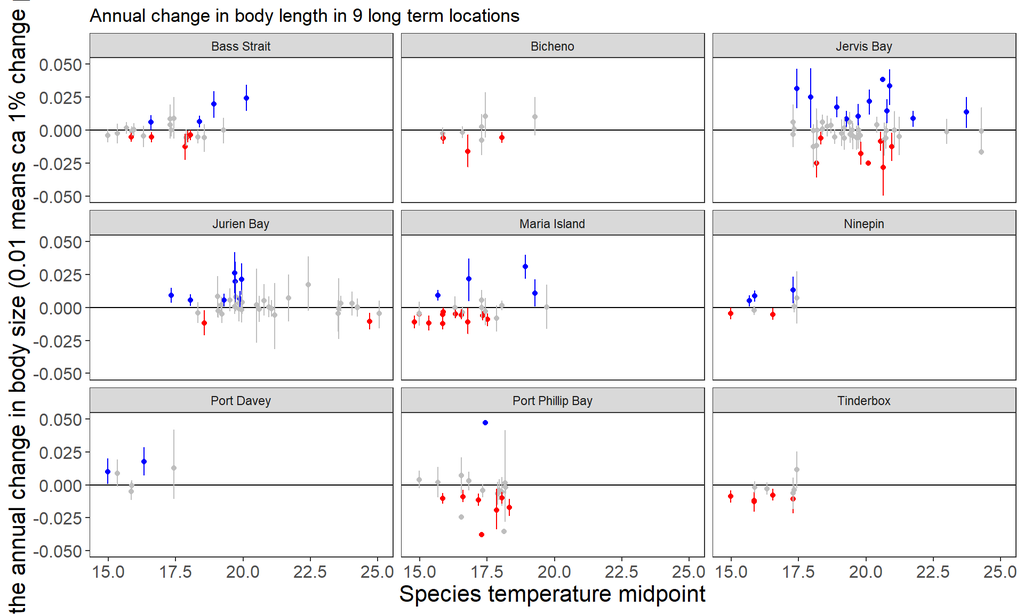

| LocFig | incr | decr | no_sp | change_spp | temptrend |
| --- | --- | --- | --- | --- | --- |
| Jurien Bay | 7 | 2 | 36 | 0.2500 | 0.0093 |
| Bass Strait | 4 | 5 | 23 | 0.3913 | 0.0229 |
| Port Phillip Bay | 1 | 7 | 22 | 0.3636 | 0.0231 |
| Port Davey | 2 | 1 | 7 | 0.4286 | 0.0237 |
| Bicheno | 0 | 3 | 9 | 0.3333 | 0.0272 |
| Ninepin | 3 | 2 | 8 | 0.6250 | 0.0273 |
| Tinderbox | 0 | 5 | 10 | 0.5000 | 0.0278 |
| Maria Island | 4 | 11 | 24 | 0.6250 | 0.0288 |
| Jervis Bay | 11 | 7 | 53 | 0.3396 | 0.0373 |

### Extended data Fig. 6: inside/outside MPA

```
##
##  Pearson's product-moment correlation
##
## data:  Params3models$inMPA50 and Params3models$outMPA50
## t = 5.7494, df = 119, p-value = 7.054e-08
## alternative hypothesis: true correlation is not equal to 0
## 95 percent confidence interval:
##  0.3138785 0.5952129
## sample estimates:
##       cor
## 0.4662526
```

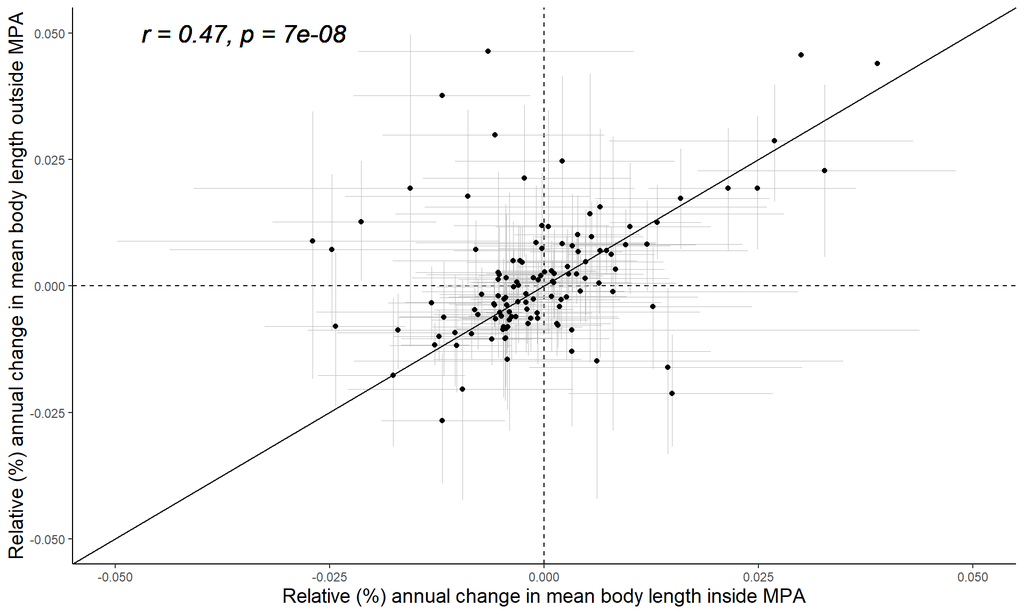

```
## [1] 69
```

### Extended Data Table 3: print temporal slopes and summary

| species | Location | MaxLength | Temp_midp | b1_p025 | b1_p10 | b1_p50 | b1_p90 | b1_p975 |
| --- | --- | --- | --- | --- | --- | --- | --- | --- |
| Acanthaluteres spilomelanurus | Port Phillip Bay | 14.0 | 16.5555 | -0.0877 | -0.0731 | -0.0243 | 0.0288 | 0.0661 |
| Acanthaluteres vittiger | Bass Strait | 35.0 | 17.2935 | -0.0143 | -0.0066 | 0.0041 | 0.0145 | 0.0199 |
| Acanthaluteres vittiger | Bicheno | 35.0 | 17.2935 | -0.0240 | -0.0190 | -0.0076 | 0.0029 | 0.0086 |
| Acanthaluteres vittiger | Jervis Bay | 35.0 | 17.2935 | -0.0159 | -0.0084 | 0.0059 | 0.0193 | 0.0262 |
| Acanthaluteres vittiger | Maria Island | 35.0 | 17.2935 | -0.0115 | -0.0079 | -0.0003 | 0.0078 | 0.0126 |
| Acanthaluteres vittiger | Port Phillip Bay | 35.0 | 17.2935 | -0.0599 | -0.0521 | -0.0378 | -0.0238 | -0.0178 |
| Acanthaluteres vittiger | Tinderbox | 35.0 | 17.2935 | -0.0283 | -0.0217 | -0.0108 | -0.0004 | 0.0061 |
| Acanthopagrus australis | Jervis Bay | 66.0 | 20.5335 | -0.0198 | -0.0159 | -0.0086 | -0.0013 | 0.0028 |
| Achoerodus viridis | Jervis Bay | 100.0 | 19.3890 | -0.0059 | -0.0014 | 0.0061 | 0.0136 | 0.0176 |
| Anampses geographicus | Jurien Bay | 31.0 | 23.5525 | -0.0374 | -0.0241 | -0.0011 | 0.0220 | 0.0367 |
| Aplodactylus arctidens | Bass Strait | 65.0 | 15.9620 | -0.0079 | -0.0044 | 0.0006 | 0.0052 | 0.0079 |
| Aplodactylus lophodon | Jervis Bay | 45.0 | 18.6945 | -0.0059 | -0.0026 | 0.0037 | 0.0088 | 0.0120 |
| Apogon limenus | Jervis Bay | 14.0 | 21.0665 | -0.0200 | -0.0124 | 0.0000 | 0.0143 | 0.0230 |
| Apogon victoriae | Jurien Bay | 14.0 | 20.6066 | -0.0163 | -0.0110 | -0.0012 | 0.0088 | 0.0158 |
| Atypichthys strigatus | Bass Strait | 25.0 | 18.9200 | 0.0051 | 0.0094 | 0.0200 | 0.0297 | 0.0368 |
| Atypichthys strigatus | Jervis Bay | 25.0 | 18.9200 | 0.0055 | 0.0096 | 0.0174 | 0.0254 | 0.0297 |
| Atypichthys strigatus | Maria Island | 25.0 | 18.9200 | 0.0172 | 0.0217 | 0.0311 | 0.0400 | 0.0449 |
| Austrolabrus maculatus | Jervis Bay | 17.0 | 19.1905 | -0.0092 | -0.0054 | 0.0016 | 0.0093 | 0.0140 |
| Austrolabrus maculatus | Jurien Bay | 17.0 | 19.1905 | -0.0068 | -0.0036 | 0.0021 | 0.0080 | 0.0121 |
| Bodianus frenchii | Jurien Bay | 49.0 | 19.9475 | 0.0013 | 0.0094 | 0.0215 | 0.0336 | 0.0409 |
| Caesioperca lepidoptera | Bass Strait | 30.0 | 16.3012 | -0.0181 | -0.0130 | -0.0045 | 0.0034 | 0.0083 |
| Caesioperca lepidoptera | Maria Island | 30.0 | 16.3012 | -0.0132 | -0.0081 | -0.0003 | 0.0085 | 0.0142 |
| Caesioperca rasor | Bass Strait | 26.0 | 15.6675 | -0.0053 | -0.0030 | 0.0015 | 0.0059 | 0.0085 |
| Caesioperca rasor | Maria Island | 26.0 | 15.6675 | 0.0032 | 0.0053 | 0.0092 | 0.0131 | 0.0155 |
| Caesioperca rasor | Ninepin | 26.0 | 15.6675 | -0.0013 | 0.0008 | 0.0050 | 0.0094 | 0.0115 |
| Caesioperca rasor | Port Phillip Bay | 26.0 | 15.6675 | -0.0169 | -0.0096 | 0.0017 | 0.0137 | 0.0203 |
| Cheilodactylus fuscus | Jervis Bay | 65.0 | 19.7820 | -0.0119 | -0.0091 | -0.0042 | 0.0008 | 0.0039 |
| Cheilodactylus nigripes | Bass Strait | 41.0 | 16.6005 | -0.0117 | -0.0095 | -0.0053 | -0.0017 | 0.0002 |
| Cheilodactylus nigripes | Port Phillip Bay | 41.0 | 16.6005 | -0.0153 | -0.0131 | -0.0090 | -0.0040 | -0.0007 |
| Cheilodactylus rubrolabiatus | Jurien Bay | 75.0 | 19.7290 | -0.0099 | -0.0028 | 0.0081 | 0.0200 | 0.0312 |

[output cut: 162 more lines]

### Combine temporal and spatial slopes

### Fig2 data and plots

```
## [1] 0.3653846
```

```
##   correlation    std.err  t.value      p.value
## Y   0.2833114 0.07883161 3.593881 0.0004429515
```

```
##   correlation   bootcor   std.err  t.value     p.value
## Y   0.2833114 0.2819394 0.1027269 2.744552 0.006059361
```

```
##   correlation   bootcor  std.err  t.value     p.value
## Y   0.2833114 0.2819363 0.100617 2.802073 0.005077537
```

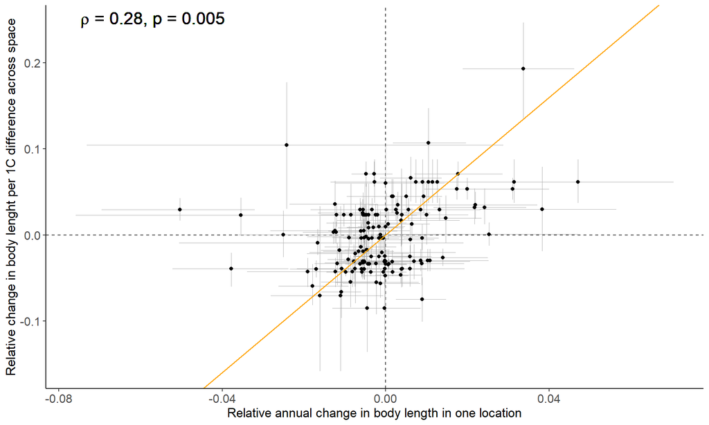